# Practica 5

Murillo Alba Josué Iván

marzo 2025

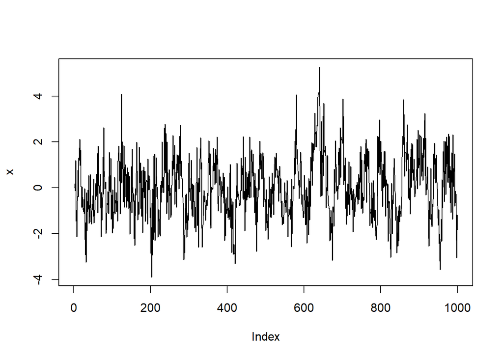

```r
n <- 1e3
w <- rnorm(n)
x <- numeric(n)
x1 <- numeric(n)
x2 <- numeric(n)
x3 <- numeric(n)

# para x
for(t in 3:n)
  x[t] <- 0.33*x[t-1] + 0.4*x[t-2] + w[t]

plot(x, type = 'l')
```

```r
# para x1
for(t in 2:n)
  x1[t] <- x[t-1]
head(x)
```

```
## [1]  0.0000000  0.0000000  0.1823907 -0.1367649  1.1858347 -1.4534753
```

```r
head(x1)
```

```
## [1]  0.0000000  0.0000000  0.0000000  0.1823907 -0.1367649  1.1858347
```

```r
# para x2
for(t in 3:n)
  x2[t] <- x[t-2]
head(x)
```

```
## [1]  0.0000000  0.0000000  0.1823907 -0.1367649  1.1858347 -1.4534753
```

```r
head(x2)
```

```
## [1]  0.0000000  0.0000000  0.0000000  0.0000000  0.1823907 -0.1367649
```

```r
# para x3
for(t in 4:n)
  x3[t] <- x[t-3]
head(x)
```

```
## [1]  0.0000000  0.0000000  0.1823907 -0.1367649  1.1858347 -1.4534753
```

```r
head(x3)
```

```
## [1] 0.0000000 0.0000000 0.0000000 0.0000000 0.0000000 0.1823907
```

```r
# para fi 1
lm(x~x1)
```

```
##
## Call:
## lm(formula = x ~ x1)
##
## Coefficients:
## (Intercept)           x1
##   -0.001155     0.552684
```

```r
#para fi 2
lm(x~x1+x2)
```

```
##
## Call:
## lm(formula = x ~ x1 + x2)
##
## Coefficients:
## (Intercept)           x1           x2
##   -0.001911     0.328699     0.406176
```

```r
#para fi 2
lm(x~x1+x2+x3)
```

```
##
## Call:
## lm(formula = x ~ x1 + x2 + x3)
##
## Coefficients:
## (Intercept)           x1           x2           x3
##   -0.002143     0.306682     0.388328     0.054560
```

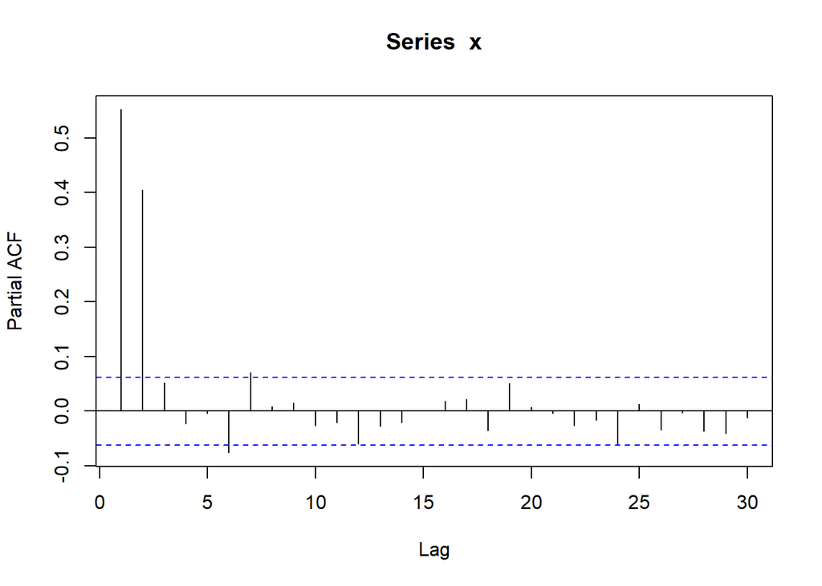

```r
# parcial
p <- pacf(x)
```

```r
p
```

```
##
## Partial autocorrelations of series 'x', by lag
##
##      1      2      3      4      5      6      7      8      9     10     11
##  0.552  0.405  0.052 -0.023 -0.004 -0.076  0.071  0.008  0.015 -0.027 -0.021
##     12     13     14     15     16     17     18     19     20     21     22
## -0.059 -0.028 -0.020  0.001  0.018  0.022 -0.036  0.051  0.007 -0.004 -0.026
##     23     24     25     26     27     28     29     30
## -0.016 -0.060  0.013 -0.034 -0.003 -0.037 -0.041 -0.012
```

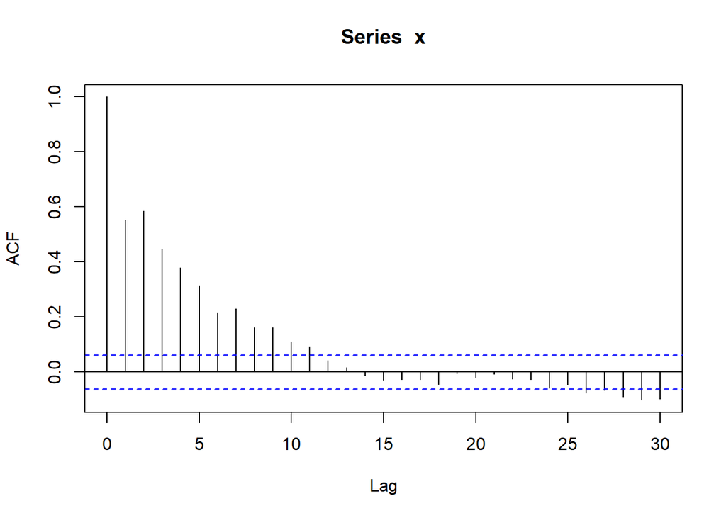

```r
# total
a <- acf(x)
```

```r
a
```

```
##
## Autocorrelations of series 'x', by lag
##
##      0      1      2      3      4      5      6      7      8      9     10
##  1.000  0.552  0.586  0.446  0.379  0.314  0.215  0.229  0.161  0.161  0.111
##     11     12     13     14     15     16     17     18     19     20     21
##  0.093  0.042  0.015 -0.012 -0.028 -0.027 -0.027 -0.044 -0.006 -0.018 -0.007
##     22     23     24     25     26     27     28     29     30
## -0.024 -0.026 -0.057 -0.047 -0.075 -0.066 -0.089 -0.102 -0.098
```

2. Grafica la funci´on de autocorrelaci´on parcial de los procesos estimada por R (usa la funci´on pacf(X)).
3. Calcula la funci´on de autocorrelaci´on parcial de los procesos dados, para los primeros 5 periodos: φ1, φ2, φ3, φ4 y φ5, usando modelos de regresi´on lineal en R, como se hizo en clase.
4. Compara estos valores que calculaste con los estimados por R con la funci´on pacf.

# A

1. Xt = 0.4Xt−1 + Wt , con X1 = 1 y X2 = 0.

## 1

Realiza una grafica con los primeros 1000 valores de los siguientes procesos estocasticos.

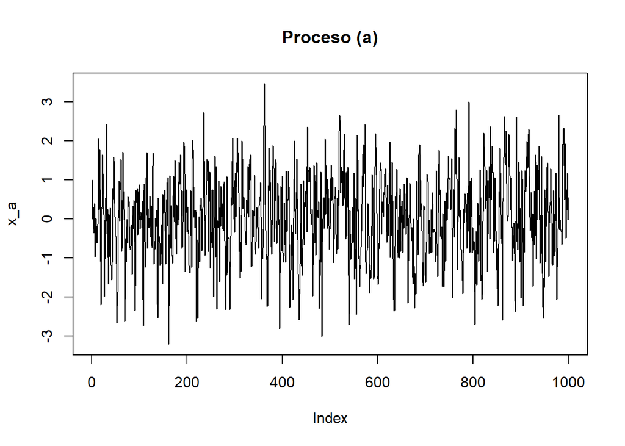

```r
w_a <- rnorm(n)
x_a <- numeric(n)
x_a[1] <- 1
x_a[2] <- 0
for(t in 3:n) x_a[t] <- 0.4 * x_a[t-1] + w_a[t]
plot(x_a, type = 'l', main = "Proceso (a)")
```

## 2

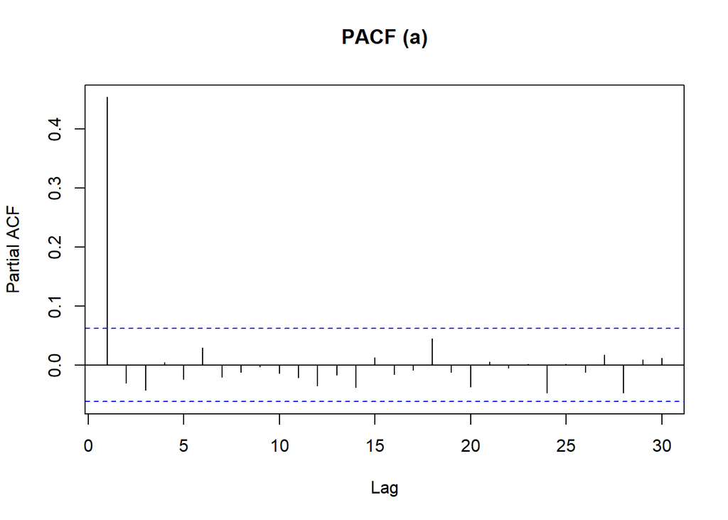

```r
pacf_r<- pacf(x_a, main = "PACF (a)")
```

```r
pacf_r
```

```
##
## Partial autocorrelations of series 'x_a', by lag
##
##      1      2      3      4      5      6      7      8      9     10     11
##  0.454 -0.031 -0.042  0.004 -0.024  0.029 -0.020 -0.012 -0.003 -0.014 -0.021
##     12     13     14     15     16     17     18     19     20     21     22
## -0.035 -0.017 -0.038  0.013 -0.016 -0.008  0.045 -0.012 -0.037  0.005 -0.004
##     23     24     25     26     27     28     29     30
##  0.002 -0.047  0.001 -0.012  0.018 -0.047  0.009  0.012
```

## 3

```r
# Scenario a: Xt = 0.4Xt−1 + Wt, con X1 = 1 y X2 = 0
set.seed(123)
n <- 1000
w <- rnorm(n)
x <- numeric(n)
x[1] <- 1  # X1 = 1
x[2] <- 0  # X2 = 0

# Generar serie temporal
for (t in 3:n) {
  x[t] <- 0.4 * x[t-1] + w[t]
}

# Preparar matrices para regresión
x1 <- numeric(n)
x1[2:n] <- x[1:(n-1)]

x2 <- numeric(n)
x2[3:n] <- x[1:(n-2)]

x3 <- numeric(n)
x3[4:n] <- x[1:(n-3)]

x4 <- numeric(n)
x4[5:n] <- x[1:(n-4)]

x5 <- numeric(n)
x5[6:n] <- x[1:(n-5)]

# Calcular PACF mediante regresiones
pacf_manual <- numeric(5)
pacf_1 <- lm(x[3:n] ~ x1[3:n])
pacf_2 <- lm(x[4:n] ~ x1[4:n] + x2[4:n])
pacf_3 <- lm(x[5:n] ~ x1[5:n] + x2[5:n] + x3[5:n])
pacf_4 <- lm(x[6:n] ~ x1[6:n] + x2[6:n] + x3[6:n] + x4[6:n])
pacf_5 <- lm(x[7:n] ~ x1[7:n] + x2[7:n] + x3[7:n] + x4[7:n] + x5[7:n])

# Mostrar coeficientes
cat("Scenario a - PACF values:\n")
```

```
## Scenario a - PACF values:
```

```r
cat("φ1:", coef(pacf_1)[2], "\n")
```

```
## φ1: 0.3622276
```

```r
cat("φ2:", coef(pacf_2)[3], "\n")
```

```
## φ2: -0.02479303
```

```r
cat("φ3:", coef(pacf_3)[4], "\n")
```

```
## φ3: -0.01635997
```

```r
cat("φ4:", coef(pacf_4)[5], "\n")
```

```
## φ4: 0.0124525
```

```r
cat("φ5:", coef(pacf_5)[6], "\n")
```

```
## φ5: -0.01797366
```

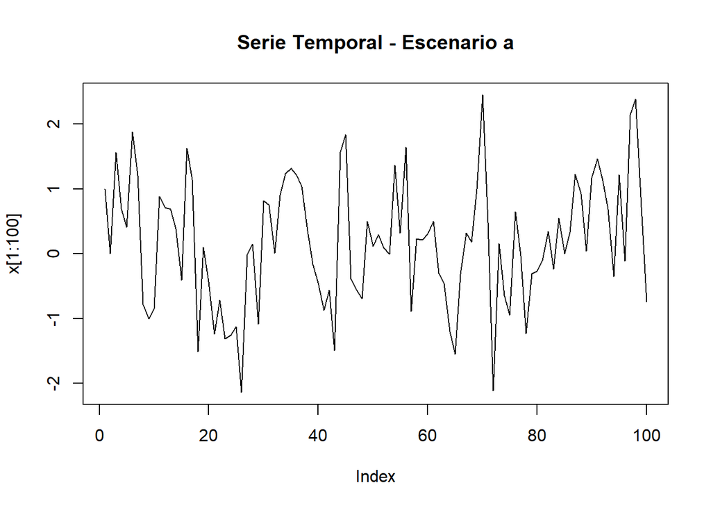

```r
# Gráfico de la serie temporal
plot(x[1:100], type='l', main='Serie Temporal - Escenario a')
```

## 4

```r
# Comparación
cat("Scenario a - PACF Comparison:\n")
```

```
## Scenario a - PACF Comparison:
```

```r
cat("Manual PACF values:\n")
```

```
## Manual PACF values:
```

```r
print(pacf_manual)
```

```
## [1] 0 0 0 0 0
```

```r
cat("\nR PACF values:\n")
```

```
##
## R PACF values:
```

```r
print(pacf_r$acf)
```

```
## , , 1
##
##               [,1]
##  [1,]  0.454194701
##  [2,] -0.030529702
##  [3,] -0.042272483
##  [4,]  0.004450144
##  [5,] -0.024062210
##  [6,]  0.028955415
##  [7,] -0.020287422
##  [8,] -0.011812595
##  [9,] -0.002602442
## [10,] -0.013944058
## [11,] -0.021328066
## [12,] -0.035398813
```

[output cut: 18 more lines]

[figure not shown]

```r
# Gráfico comparativo
par(mfrow=c(1,2))
plot(pacf_manual, type='h', main='Manual PACF', ylim=c(-1,1))
abline(h=0)
plot(pacf_r$acf, type='h', main='R PACF', ylim=c(-1,1))
abline(h=0)
```

# B

Xt = 0.3Xt-2 - 0.5Xt-1 + Wt con X1 = 0 y X2 = 1.

## 1

Realiza una grafica con los primeros 1000 valores de los siguientes procesos estocasticos.

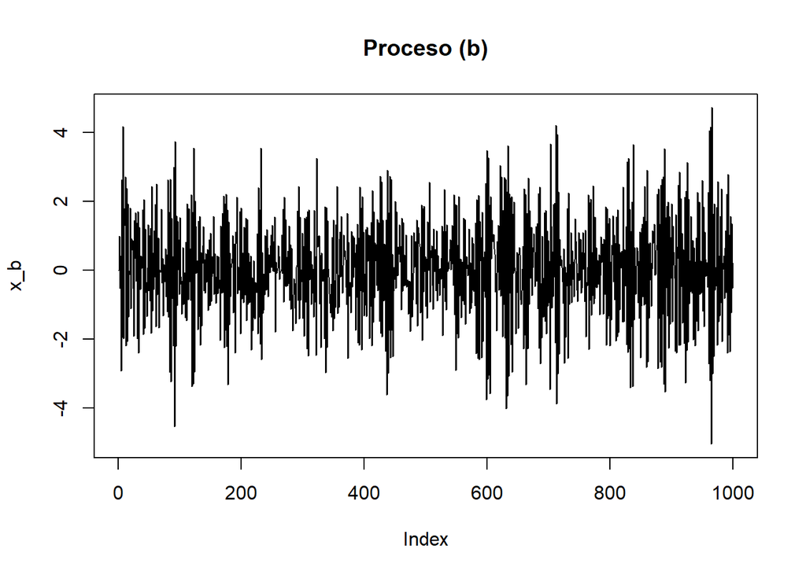

```r
w_b <- rnorm(n)
x_b <- numeric(n)
x_b[1] <- 0
x_b[2] <- 1
for(t in 3:n) x_b[t] <- 0.3 * x_b[t-2] - 0.5 * x_b[t-1] + w_b[t]

plot(x_b, type = 'l', main = "Proceso (b)")
```

## 2

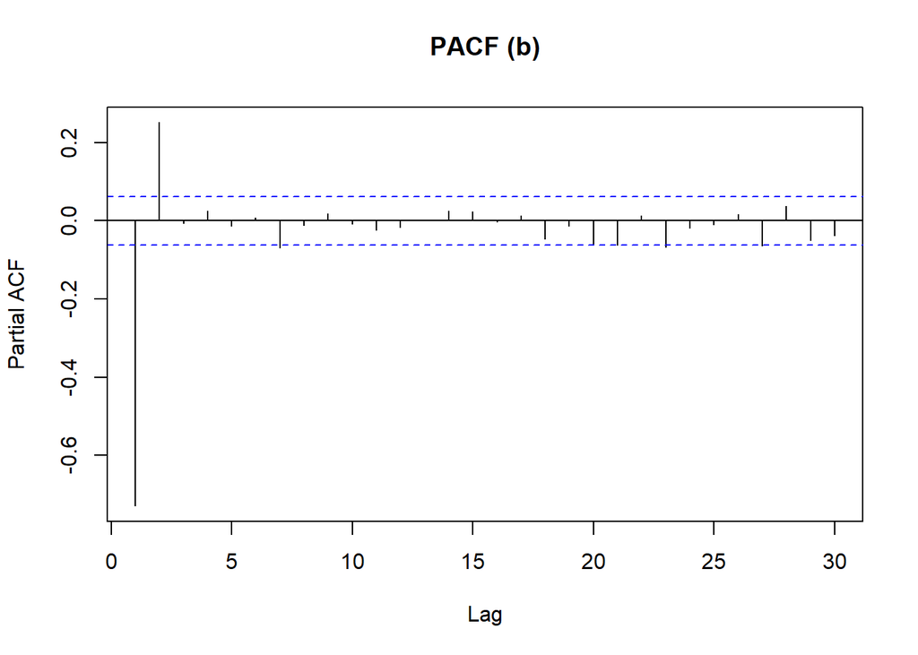

```r
pacf_l<-pacf(x_b, main = "PACF (b)")
```

## 3

```r
# Scenario b: Xt = 0.3Xt−2 − 0.5Xt−1 + Wt, con X1 = 0 y X2 = 1
set.seed(123)
n <- 1000
w <- rnorm(n)
x <- numeric(n)
x[1] <- 0  # X1 = 0
x[2] <- 1  # X2 = 1

# Generar serie temporal
for (t in 3:n) {
  x[t] <- 0.3 * x[t-2] - 0.5 * x[t-1] + w[t]
}

# Preparar matrices para regresión
x1 <- numeric(n)
x1[2:n] <- x[1:(n-1)]

x2 <- numeric(n)
x2[3:n] <- x[1:(n-2)]

x3 <- numeric(n)
x3[4:n] <- x[1:(n-3)]

x4 <- numeric(n)
x4[5:n] <- x[1:(n-4)]

x5 <- numeric(n)
x5[6:n] <- x[1:(n-5)]

# Calcular PACF mediante regresiones
pacf_manual2 <- numeric(5)
pacf_1 <- lm(x[3:n] ~ x1[3:n])
pacf_2 <- lm(x[4:n] ~ x1[4:n] + x2[4:n])
pacf_3 <- lm(x[5:n] ~ x1[5:n] + x2[5:n] + x3[5:n])
pacf_4 <- lm(x[6:n] ~ x1[6:n] + x2[6:n] + x3[6:n] + x4[6:n])
pacf_5 <- lm(x[7:n] ~ x1[7:n] + x2[7:n] + x3[7:n] + x4[7:n] + x5[7:n])

# Mostrar coeficientes
cat("Scenario b - PACF values:\n")
```

```
## Scenario b - PACF values:
```

```r
cat("φ1:", coef(pacf_1)[2], "\n")
```

```
## φ1: -0.7270442
```

```r
cat("φ2:", coef(pacf_2)[3], "\n")
```

```
## φ2: 0.2647929
```

```r
cat("φ3:", coef(pacf_3)[4], "\n")
```

```
## φ3: -0.02579305
```

```r
cat("φ4:", coef(pacf_4)[5], "\n")
```

```
## φ4: -0.0167906
```

```r
cat("φ5:", coef(pacf_5)[6], "\n")
```

```
## φ5: 0.01631639
```

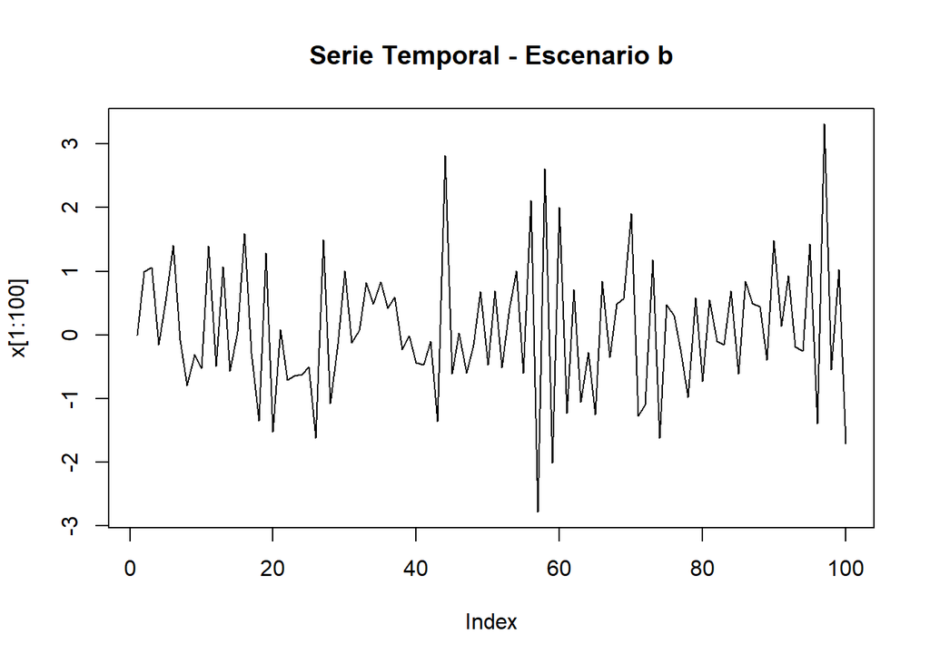

```r
# Gráfico de la serie temporal
plot(x[1:100], type='l', main='Serie Temporal - Escenario b')
```

## 4

```r
# Comparación
cat("Scenario b - PACF Comparison:\n")
```

```
## Scenario b - PACF Comparison:
```

```r
cat("Manual PACF values:\n")
```

```
## Manual PACF values:
```

```r
print(pacf_manual2)
```

```
## [1] 0 0 0 0 0
```

```r
cat("\nR PACF values:\n")
```

```
##
## R PACF values:
```

```r
print(pacf_l$acf)
```

```
## , , 1
##
##               [,1]
##  [1,] -0.728983804
##  [2,]  0.251216092
##  [3,] -0.007030049
##  [4,]  0.025662972
##  [5,] -0.013059957
##  [6,]  0.008408638
##  [7,] -0.068742089
##  [8,] -0.011955079
##  [9,]  0.018109277
## [10,] -0.007213029
## [11,] -0.023119592
## [12,] -0.016748656
```

[output cut: 18 more lines]

[figure not shown]

```r
# Gráfico comparativo
par(mfrow=c(1,2))
plot(pacf_manual2, type='h', main='Manual PACF', ylim=c(-1,1))
abline(h=0)
plot(pacf_l$acf, type='h', main='R PACF', ylim=c(-1,1))
abline(h=0)
```

# C

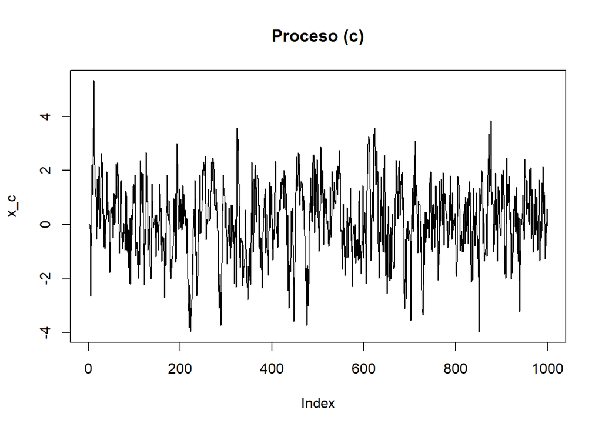

```r
w_c <- rnorm(n)
x_c <- numeric(n)
x_c[1] <- 0
x_c[2] <- 0
for(t in 3:n) x_c[t] <- 0.7 * x_c[t-1] + w_c[t]
plot(x_c, type = 'l', main = "Proceso (c)")
```

## 2

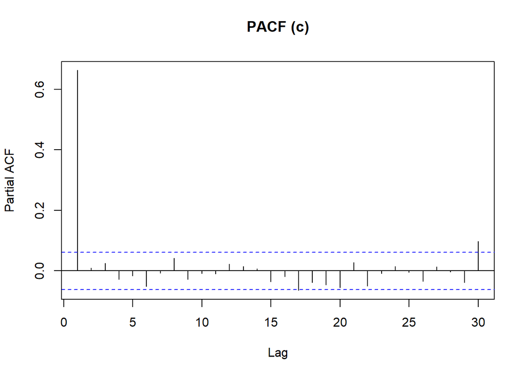

```r
pacf_m <- pacf(x_c, main = "PACF (c)")
```

## 3

```r
# Scenario c: Xt = 0.7Xt−1 + Wt, con X1 = 0 y X2 = 0
set.seed(123)
n <- 1000
w <- rnorm(n)
x <- numeric(n)
x[1] <- 0  # X1 = 0
x[2] <- 0  # X2 = 0

# Generar serie temporal
for (t in 3:n) {
  x[t] <- 0.7 * x[t-1] + w[t]
}

# Preparar matrices para regresión
x1 <- numeric(n)
x1[2:n] <- x[1:(n-1)]

x2 <- numeric(n)
x2[3:n] <- x[1:(n-2)]

x3 <- numeric(n)
x3[4:n] <- x[1:(n-3)]

x4 <- numeric(n)
x4[5:n] <- x[1:(n-4)]

x5 <- numeric(n)
x5[6:n] <- x[1:(n-5)]

# Calcular PACF mediante regresiones
pacf_manual3 <- numeric(5)
pacf_1 <- lm(x[3:n] ~ x1[3:n])
pacf_2 <- lm(x[4:n] ~ x1[4:n] + x2[4:n])
pacf_3 <- lm(x[5:n] ~ x1[5:n] + x2[5:n] + x3[5:n])
pacf_4 <- lm(x[6:n] ~ x1[6:n] + x2[6:n] + x3[6:n] + x4[6:n])
pacf_5 <- lm(x[7:n] ~ x1[7:n] + x2[7:n] + x3[7:n] + x4[7:n] + x5[7:n])

# Mostrar coeficientes
cat("Scenario c - PACF values:\n")
```

```
## Scenario c - PACF values:
```

```r
cat("φ1:", coef(pacf_1)[2], "\n")
```

```
## φ1: 0.6663828
```

```r
cat("φ2:", coef(pacf_2)[3], "\n")
```

```
## φ2: -0.007106815
```

```r
cat("φ3:", coef(pacf_3)[4], "\n")
```

```
## φ3: 0.004310496
```

```r
cat("φ4:", coef(pacf_4)[5], "\n")
```

```
## φ4: 0.02418154
```

```r
cat("φ5:", coef(pacf_5)[6], "\n")
```

```
## φ5: -0.007610375
```

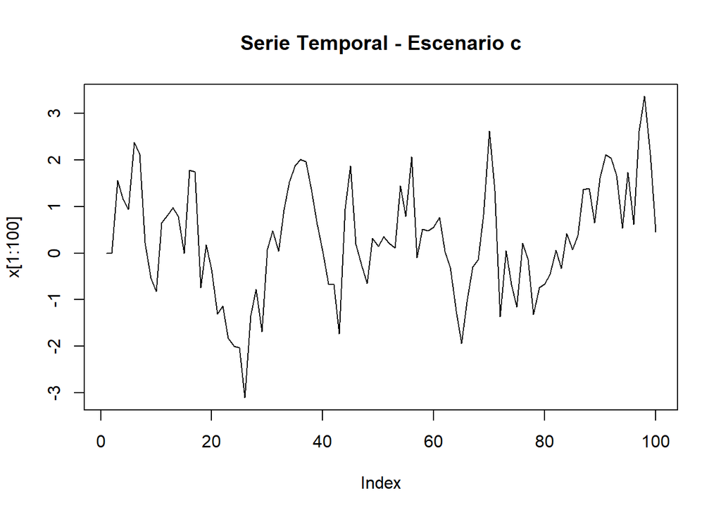

```r
# Gráfico de la serie temporal
plot(x[1:100], type='l', main='Serie Temporal - Escenario c')
```

## 4

```r
# Comparación
cat("Scenario c - PACF Comparison:\n")
```

```
## Scenario c - PACF Comparison:
```

```r
cat("Manual PACF values:\n")
```

```
## Manual PACF values:
```

```r
print(pacf_manual3)
```

```
## [1] 0 0 0 0 0
```

```r
cat("\nR PACF values:\n")
```

```
##
## R PACF values:
```

```r
print(pacf_m$acf)
```

```
## , , 1
##
##               [,1]
##  [1,]  0.662702315
##  [2,]  0.009978692
##  [3,]  0.025697351
##  [4,] -0.027373823
##  [5,] -0.016203129
##  [6,] -0.051595553
##  [7,] -0.006811093
##  [8,]  0.041464855
##  [9,] -0.027918807
## [10,] -0.009106428
## [11,] -0.009771484
## [12,]  0.022609498
```

[output cut: 18 more lines]

[figure not shown]

```r
# Gráfico comparativo
par(mfrow=c(1,2))
plot(pacf_manual3, type='h', main='Manual PACF', ylim=c(-1,1))
abline(h=0)
plot(pacf_m$acf, type='h', main='R PACF', ylim=c(-1,1))
abline(h=0)
```

# D

Xt = 0.2Xt−1 + 0.3Xt−2 + Wt , con X1 = 1 y X2 = 0.

## 1

Realiza una gr´afica con los primeros 1000 valores de los siguientes procesos estoc´asticos.

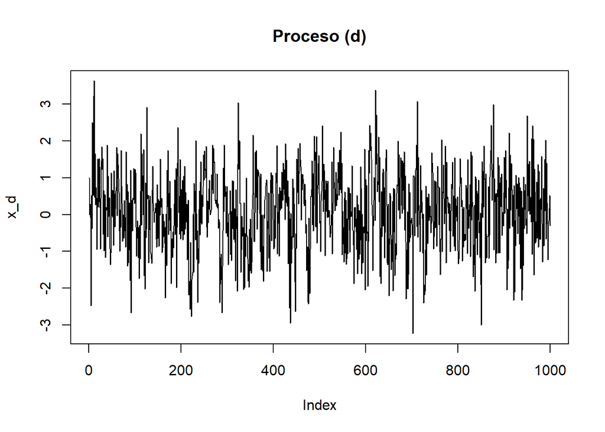

```r
w_d <- rnorm(n)
x_d <- numeric(n)
x_d[1] <- 1
x_d[2] <- 0
for(t in 3:n) x_d[t] <- 0.2 * x_d[t-1] + 0.3 * x_d[t-2] + w_d[t]
plot(x_d, type = 'l', main = "Proceso (d)")
```

## 2

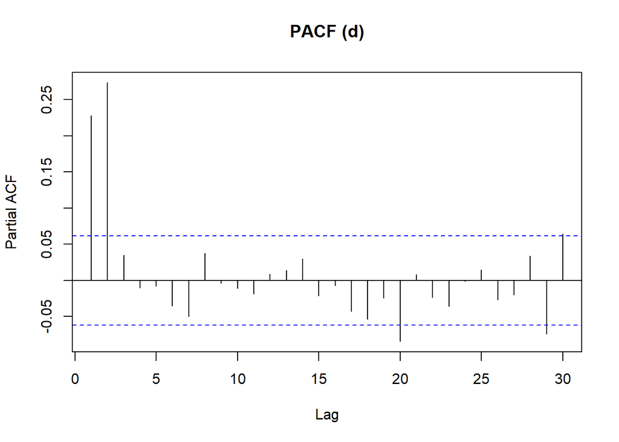

```r
pacf_n <- pacf(x_d, main = "PACF (d)")
```

## 3

```r
# Scenario d: Xt = 0.2Xt−1 + 0.3Xt−2 + Wt, con X1 = 1 y X2 = 0
set.seed(123)
n <- 1000
w <- rnorm(n)
x <- numeric(n)
x[1] <- 1  # X1 = 1
x[2] <- 0  # X2 = 0

# Generar serie temporal
for (t in 3:n) {
  x[t] <- 0.2 * x[t-1] + 0.3 * x[t-2] + w[t]
}

# Preparar matrices para regresión
x1 <- numeric(n)
x1[2:n] <- x[1:(n-1)]

x2 <- numeric(n)
x2[3:n] <- x[1:(n-2)]

x3 <- numeric(n)
x3[4:n] <- x[1:(n-3)]

x4 <- numeric(n)
x4[5:n] <- x[1:(n-4)]

x5 <- numeric(n)
x5[6:n] <- x[1:(n-5)]

# Calcular PACF mediante regresiones
pacf_manual4 <- numeric(5)
pacf_1 <- lm(x[3:n] ~ x1[3:n])
pacf_2 <- lm(x[4:n] ~ x1[4:n] + x2[4:n])
pacf_3 <- lm(x[5:n] ~ x1[5:n] + x2[5:n] + x3[5:n])
pacf_4 <- lm(x[6:n] ~ x1[6:n] + x2[6:n] + x3[6:n] + x4[6:n])
pacf_5 <- lm(x[7:n] ~ x1[7:n] + x2[7:n] + x3[7:n] + x4[7:n] + x5[7:n])

# Mostrar coeficientes
cat("Scenario d - PACF values:\n")
```

```
## Scenario d - PACF values:
```

```r
cat("φ1:", coef(pacf_1)[2], "\n")
```

```
## φ1: 0.2314842
```

```r
cat("φ2:", coef(pacf_2)[3], "\n")
```

```
## φ2: 0.2801914
```

```r
cat("φ3:", coef(pacf_3)[4], "\n")
```

```
## φ3: -0.01545782
```

```r
cat("φ4:", coef(pacf_4)[5], "\n")
```

```
## φ4: 0.02538861
```

```r
cat("φ5:", coef(pacf_5)[6], "\n")
```

```
## φ5: -0.006028984
```

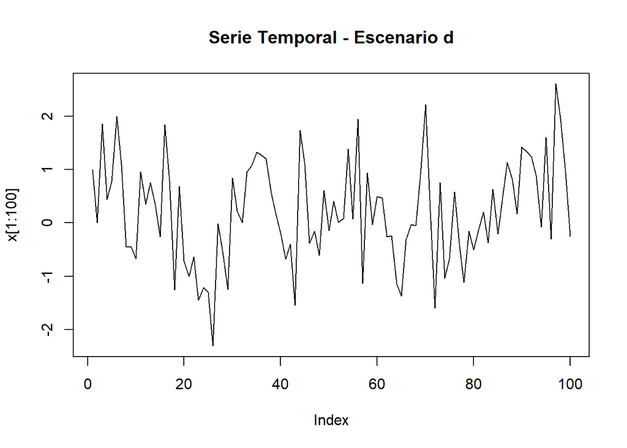

```r
# Gráfico de la serie temporal
plot(x[1:100], type='l', main='Serie Temporal - Escenario d')
```

## 4

```r
# Comparación
cat("Scenario d - PACF Comparison:\n")
```

```
## Scenario d - PACF Comparison:
```

```r
cat("Manual PACF values:\n")
```

```
## Manual PACF values:
```

```r
print(pacf_manual4)
```

```
## [1] 0 0 0 0 0
```

```r
cat("\nR PACF values:\n")
```

```
##
## R PACF values:
```

```r
print(pacf_n$acf)
```

```
## , , 1
##
##               [,1]
##  [1,]  0.228277930
##  [2,]  0.273593370
##  [3,]  0.034704954
##  [4,] -0.010554166
##  [5,] -0.007818860
##  [6,] -0.035149421
##  [7,] -0.049529777
##  [8,]  0.037669561
##  [9,] -0.003688193
## [10,] -0.010915001
## [11,] -0.018644303
## [12,]  0.008952865
```

[output cut: 18 more lines]

[figure not shown]

```r
# Gráfico comparativo
par(mfrow=c(1,2))
plot(pacf_manual4, type='h', main='Manual PACF', ylim=c(-1,1))
abline(h=0)
plot(pacf_n$acf, type='h', main='R PACF', ylim=c(-1,1))
abline(h=0)
```